# Choosing Hypothesis Using Confidence Intervals

## How Do We Choose Between Hypotheses?

Once we set up our null and alternative hypotheses, we need to use data to figure out which hypothesis we actually think is more likely to be true. And there are two ways we might approach choosing one of these hypotheses. One is the approach we saw using the confidence intervals, where we simulate the sampling distributions of our statistic, and then we could see if our hypothesis is consistent with what we observe in the sampling distribution. The second way we could approach choosing a hypothesis is simulating what we believe to be possible under the null and then seeing if our data is actually consistent with that. This is what professionals tend to do in a hypothesis testing.

We are using the approach of confidence intervals below to illustrate the above said.

What if we wanted to ask the question of if the average height for all coffee drinkers is greater than 70 inches. We could set up our null and alternative hypotheses in the following way.

[figure not shown]

```python
import pandas as pd
import numpy as np
import matplotlib.pyplot as plt

%matplotlib inline
np.random.seed(42)

df = pd.read_csv('coffee_dataset.csv')
```

```python
sample_df = df.sample(150)
```

```python
bootsample = sample_df.sample(150, replace=True)
```

```python
means = []
for _ in range(10000):
    bootsample = sample_df.sample(150, replace=True)
    means.append(bootsample.height.mean())
```

```python
lower, high = np.percentile(means, 2.5), np.percentile(means, 97.5)
```

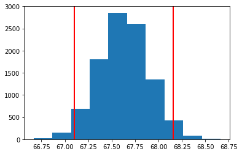

```python
plt.hist(means)
plt.axvline(x=lower, color='r', linewidth=2)
plt.axvline(x=high, color='r', linewidth=2)
```

Using your confidence interval, you can simply look at if the interval falls in the null hypothesis space or in the alternative hypothesis space to choose which hypothesis you believe to be true.

In the above case, our interval was entirely below 70, which would suggest the null (the population mean is less than 70) is actually true.